**[AWS] EC2 구축 하기(Doing)**

[figure not shown]

데이터 분석을 위한 AWS사용 가이드를 써보려 한다. AWS는 Amazon Web Service의 준말로 **어디어디**에서 표현하기를 Cloud Cloud Cloud 라고들 표현 하는데, 이를 그나마 좀 쉽게 표현을 해보자면 **허공에 풍선달린 컴퓨터를 하나 띄워놓고, 필요할때마다 가져와서 사용하는 개념?** 정도로 생각을 하면 좋을 것 같다. 그동안 최소한의 기능만을 사용해보다가 이번에 좀 더 적극적으로 사용할 계기가 생겨 공부도 할겸 정리도 하는 시간을 가져 보려고 한다.

- EC2 구축
- EC2 Tier 업그레이드 / 용량 업그레이드
- EC2 한글폰트 적용
- EC2에 에서 R/Python 설치
- S3 스토리지 사용
- RDS 사용

등등 여러가지를 하나씩 써내려 가면서도 추가로 AWS 생태계에 관심을 가지고 공부를 하면 될것 같다. 이번에는 우선 EC2를 구축하여 하나의 서버를 띄우는 내용을 적어보려 한다.

# EC2 란?

Elastic Compute Cloud의 준말로 가상의 운영체제를 만들어 사용가능하게 해주는 서비스 라고 보면 된다. 이제 부터 이곳에 R/python 을 설치에 분석 환경을 가추어 나갈 생각이다. 설치 과정을 하나씩 알아보자.

# Step1

[figure not shown]

# Step2

[figure not shown]

# Step3

[figure not shown]

# Step4

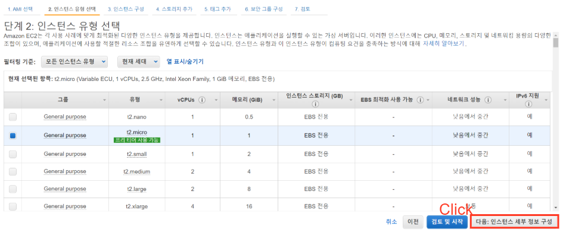

# Step5

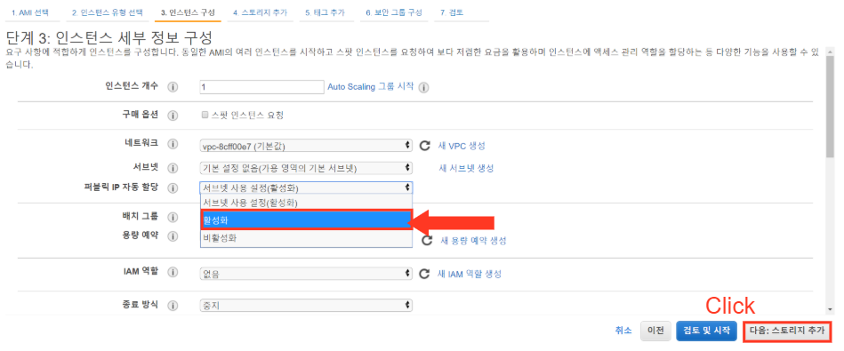

# Step 6

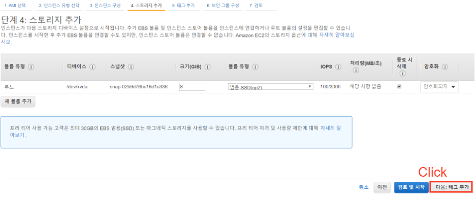

# Step 7

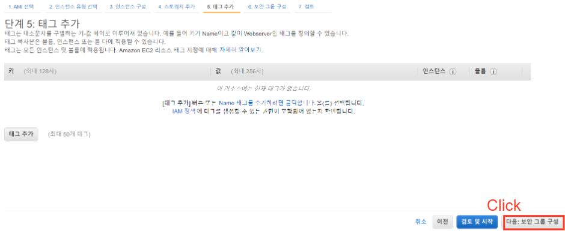

# Step 8

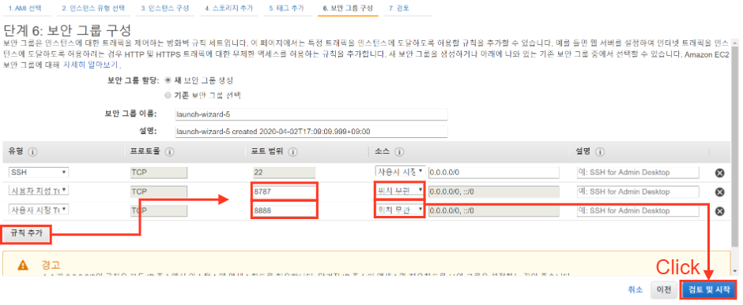

# Step 9

[figure not shown]

# Step 10

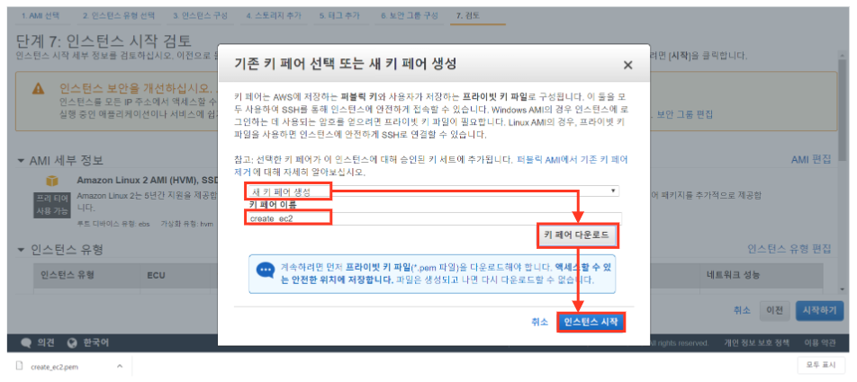

# Step 11

[figure not shown]

# Step 12

[figure not shown]

# Step 13

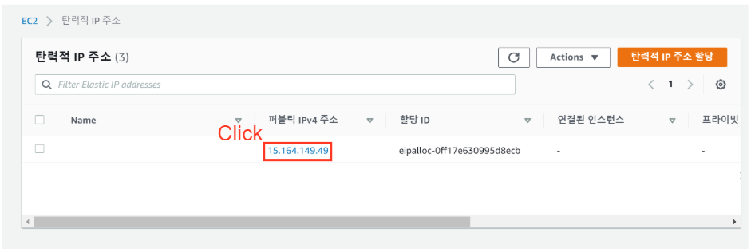

# Step 14

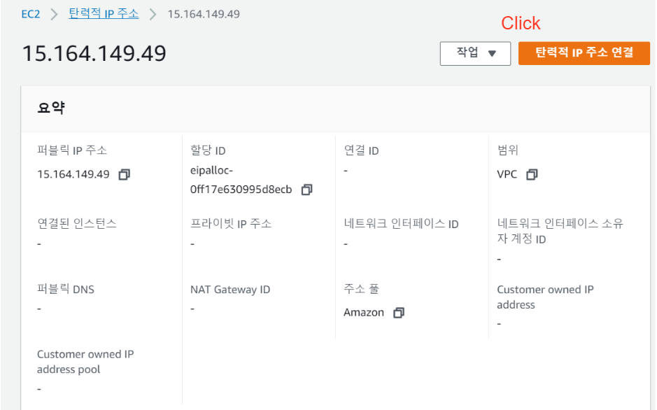

# Step 15

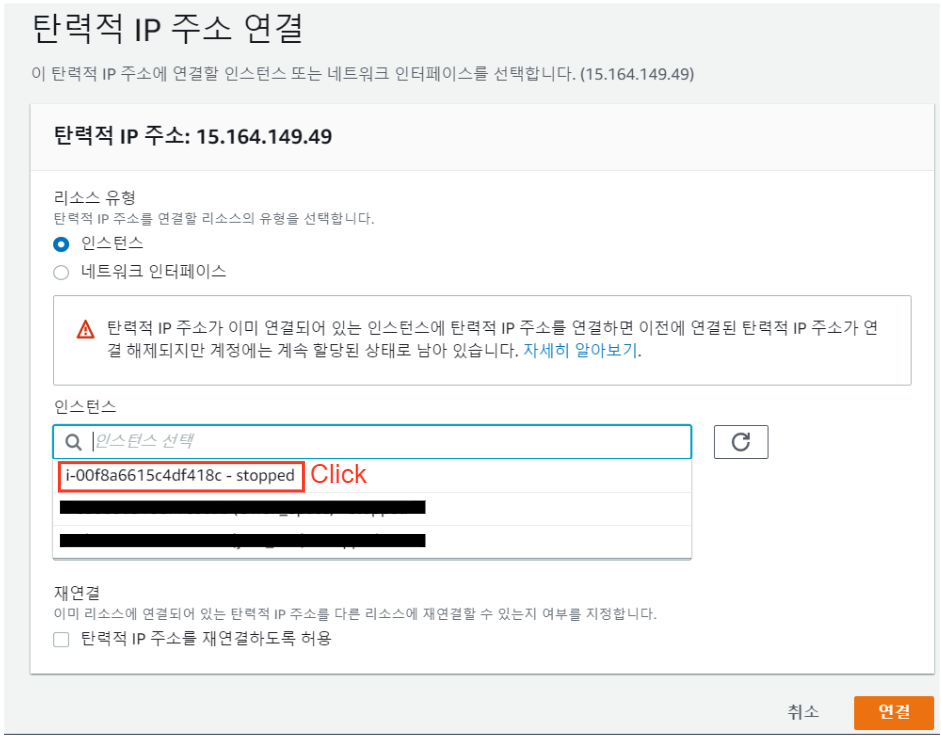

# Step 16

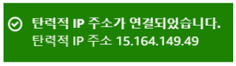

# Step 17

[figure not shown]

# Step 18

[figure not shown]

# Step 19

[figure not shown]

# Step 20

[figure not shown]

# Step 21

[figure not shown]

# Step 22

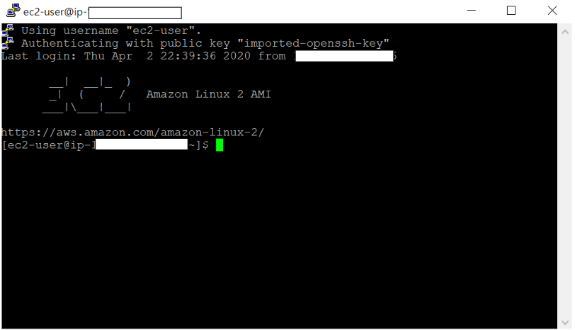

# Step 23

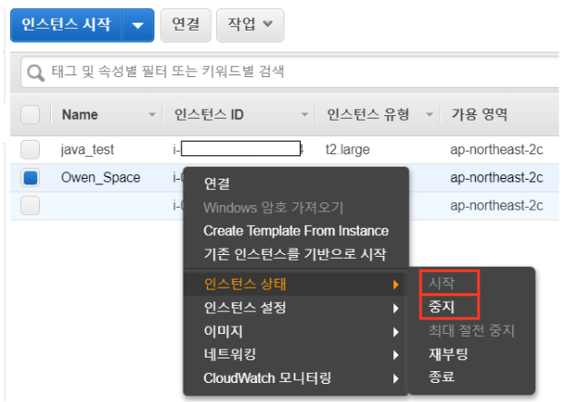